# Analiza zbioru danych Protein Data Bank (PDB)

Łukasz Kiszka

29 styczeń, 2016

### Spis treści

1. Podsumowanie analizy danych
2. Wykorzystane biblioteki
3. Wczytanie danych z pliku oraz wstępne czyszczenie danych
4. Podsumowanie wartości w kolumnach
5. Korelacje między zmiennymi
6. Liczba przypadków dla każdej z klas (res_name)
7. Wykresy rozkładu liczby atomów i elektronów
8. Próba odtworzenia wykresu z wymagań
9. Klasy z największą niezgodnością liczby atomów
10. Klasy z największą niezgodnością liczby elektronów
11. Rozkład wartości kolumn part_01
12. Przewidywanie liczby elektronów i atomów na podstawie innych kolumn
13. Klasyfikator

# Posumowanie analizy zbioru danych

W danych znajdowało się bardzo dużo wartości NA. W obliczeniach w zależności co było liczone zostały one zamienione lub pominięte - szczególnie podczas obliczania korelacji (sposob obsługi wartości NA podczas obliczania korelacji został opisany w punkcie 5).

Zauważono także, że kolumny fo_col fc_col zawierają tylko 1 wartość. Powinny one zostać usunięte ze zbioru przy próbie utworzenia klasyfikatora.

Podczas rysowania wykresów dla kolumn zaczynających się od part_01 zauważono, że dużo wartości jest skupionych w okolicy zera.

# Wykorzystane biblioteki

```r
library(knitr)
library(ggplot2)
library(dplyr)
library(ggExtra)
library(caret)
library(corrplot)
```

# Wczytanie danych z pliku oraz wstępne czyszczenie danych

Wczytanie danych z pliku. Za pomocą heurystyki wyznaczam typy danych.

```r
initial <- read.table("all_summary.txt", nrows = 15000, sep = ';', comment.char = "", na.strings = 'nan', header = TRUE)

classes <- sapply(initial, class)
rawData <- read.table("all_summary.txt", sep = ';', comment.char = "", na.strings = 'nan', header = TRUE, colClasses = classes)
```

Załadowano 40309 wierszy, które mają 795 zmiennych.

Usuwanie z danych wiersze posiadające wartość zmiennej res_name równą: “DA”,“DC”,“DT”, “DU”, “DG”, “DI”,“UNK”, “UNX”, “UNL”, “PR”, “PD”, “Y1”, “EU”, “N”, “15P”, “UQ”, “PX4” lub “NAN

```r
selectedData  <-  selectedData  <-  rawData %>% filter(!(res_name %in% c('DA','DC','DT', 'DU', 'DG', 'DI','UNK', 'UNX', 'UNL', 'PR', 'PD', 'Y1', 'EU', 'N', '15P', 'UQ', 'PX4', 'NAN')))
```

Unikatowe pary wartości (pdb_code, res_name)

```r
unique_pdb_code_res_name  <-  selectedData[!duplicated(select(selectedData, pdb_code, res_name)),]
```

Unikatowych par wartości pdb_code, res_name jest 14132.

# Podsumowanie wartości w kolumnach

|  | title | pdb_code | res_name | res_id | chain_id | local_BAa | local_NPa | local_Ra | local_RGa | local_SRGa | local_CCSa | local_CCPa | local_ZOa | local_ZDa | local_ZD_minus_a | local_ZD_plus_a | local_res_atom_count | local_res_atom_non_h_count | local_res_atom_non_h_occupancy_sum | local_res_atom_non_h_electron_sum | local_res_atom_non_h_electron_occupancy_sum | local_res_atom_C_count | local_res_atom_N_count | local_res_atom_O_count | local_res_atom_S_count | dict_atom_non_h_count | dict_atom_non_h_electron_sum | dict_atom_C_count | dict_atom_N_count | … |
| --- | --- | --- | --- | --- | --- | --- | --- | --- | --- | --- | --- | --- | --- | --- | --- | --- | --- | --- | --- | --- | --- | --- | --- | --- | --- | --- | --- | --- | --- | --- |
|  | 1i12 ACO 1202 C: 5 | 3g6e : 196 | SO4 : 4805 | 501 : 976 | A :18044 | Mode:logical | Mode:logical | Mode:logical | Mode:logical | Mode:logical | Mode:logical | Mode:logical | Mode:logical | Mode:logical | Mode:logical | Mode:logical | Min. : 1.00 | Min. : 1.00 | Min. : 0.00 | Min. : 3.00 | Min. : 0.0 | Min. : 0.000 | Min. : 0.000 | Min. : 0.000 | Min. :0.000 | Min. : 1.00 | Min. : 3.0 | Min. : 0.000 | Min. : 0.000 | … |
|  | 1un8 MYY 1551 A: 5 | 1vql : 194 | MG : 2459 | 301 : 968 | B : 8426 | NA’s:40309 | NA’s:40309 | NA’s:40309 | NA’s:40309 | NA’s:40309 | NA’s:40309 | NA’s:40309 | NA’s:40309 | NA’s:40309 | NA’s:40309 | NA’s:40309 | 1st Qu.: 1.00 | 1st Qu.: 1.00 | 1st Qu.: 1.00 | 1st Qu.: 30.00 | 1st Qu.: 28.8 | 1st Qu.: 0.000 | 1st Qu.: 0.000 | 1st Qu.: 0.000 | 1st Qu.:0.000 | 1st Qu.: 1.00 | 1st Qu.: 30.0 | 1st Qu.: 0.000 | 1st Qu.: 0.000 | … |
|  | 4eqr COA 505 A : 5 | 3pio : 189 | ZN : 2307 | 401 : 890 | C : 3595 | NA | NA | NA | NA | NA | NA | NA | NA | NA | NA | NA | Median : 6.00 | Median : 6.00 | Median : 6.00 | Median : 48.00 | Median : 48.0 | Median : 3.000 | Median : 0.000 | Median : 3.000 | Median :0.000 | Median : 6.00 | Median : 48.0 | Median : 3.000 | Median : 0.000 | … |
|  | 4jd3 COA 402 B : 5 | 4dr5 : 185 | GOL : 1944 | 201 : 852 | D : 2685 | NA | NA | NA | NA | NA | NA | NA | NA | NA | NA | NA | Mean : 12.91 | Mean : 12.81 | Mean : 12.47 | Mean : 98.11 | Mean : 94.9 | Mean : 6.922 | Mean : 1.217 | Mean : 3.718 | Mean :0.246 | Mean : 13.28 | Mean :101.3 | Mean : 7.179 | Mean : 1.228 | … |
|  | 1dgb NDP 1301 C: 4 | 3cpw : 183 | CA : 1878 | 1 : 731 | E : 1204 | NA | NA | NA | NA | NA | NA | NA | NA | NA | NA | NA | 3rd Qu.: 18.00 | 3rd Qu.: 18.00 | 3rd Qu.: 16.80 | 3rd Qu.:128.00 | 3rd Qu.:122.0 | 3rd Qu.:10.000 | 3rd Qu.: 1.000 | 3rd Qu.: 5.000 | 3rd Qu.:0.000 | 3rd Qu.: 19.00 | 3rd Qu.:136.0 | 3rd Qu.:10.000 | 3rd Qu.: 1.000 | … |
|  | 1dre NAP 164 A : 4 | 2uua : 169 | NAG : 1633 | 500 : 539 | F : 839 | NA | NA | NA | NA | NA | NA | NA | NA | NA | NA | NA | Max. :178.00 | Max. :104.00 | Max. :104.00 | Max. :800.00 | Max. :800.0 | Max. :81.000 | Max. :15.000 | Max. :55.000 | Max. :9.000 | Max. :128.00 | Max. :866.0 | Max. :81.000 | Max. :20.000 | … |
|  | (Other) :40281 | (Other):39193 | (Other):25283 | (Other):35353 | (Other): 5516 | NA | NA | NA | NA | NA | NA | NA | NA | NA | NA | NA | NA | NA | NA | NA | NA | NA | NA | NA | NA | NA’s :82 | NA’s :82 | NA’s :82 | NA’s :82 | … |

# Korelacje między zmiennymi

Do obliczenia korelacji użytko funkcji >cor< z parametrem >use = “pairwise.complete.obs<, który ignoruje w obliczeniach korelacji dla danej pary wartości NA.

Podczas obliczania korelacji zauważono, że dla wszystkich kolumn part_XX jest ona bardzo podobna. W przedstawionej graficznej reprezentacji korelacji zabrano zmienne z part_01, by ograniczyć liczbę danych. Poza kolumnami part_01 w macierzy widzimy kolumy local_res_atom_non_h_electron_sum, local_res_atom_non_h_count, solvent_mask_count, void_mask_count, modeled_mask_count, solvent_ratio. Wybrano takie kolumny, ponieważ te kolumny będą brały w wyznaczaniu klasyfikatora.

Zmienne zostały posortowane wg algorytmu “FPC” (First Principal Component).

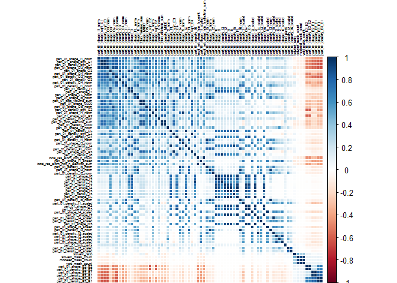

```r
correlation_data  <- cor(data, use = "pairwise.complete.obs")
corrplot(correlation_data, method = "color", tl.cex = 0.4, order = "FPC", tl.col="black")
```

Zbyt duża ilość zmiennych niestety psuje czytelność powyższej macierzy. Diagram jest bardziej czytelny w postaci pliku pdf. Plik pdf reprezentujący macierz został dodany do repozytorium po nazwą corrplot_results.pdf. Proszę o zapoznanie się z jego zawartością podczas analizy raportu.

# Liczba przypadków dla każdej z klas (res_name)

| count | class |
| --- | --- |
| 1 | 006, 010, 01K, 027, 02P, 031, 03P, 03Q, 03R, 043, 048, 04C, 04L, 056, 057, 05B, 065, 06W, 074, 07V, 085, 08B, 08E, 08R, 091, 098, 09B, 09M, 09N, 0B3, 0BB, 0BT, 0C2, 0C5, 0DJ, 0ET, 0F9, 0FN, 0FQ, 0FX, … |
| 2 | 08Q, 0MO, 128, 13P, 144, 149, 1CA, 1GP, 1MA, 250, 2AL, 2AN, 2CV, 2DA, 2OP, 2PG, 3HX, 3PG, 3TR, 4IP, 4MO, 4NP, 5FU, 5MY, 64T, A1R, A2P, AB1, ABJ, ABN, ACR, AD9, ADA, AG7, AKR, ALF, AM2, ANK, APJ, AS0, … |
| 3 | 017, 0AF, 1BO, 1PG, 2GP, 3CN, 3CO, 3TL, 5IU, A2M, A5P, ACD, AG2, ALC, AME, ARB, ASJ, B3P, B4P, BCD, BMP, BNZ, BTI, BU1, BU3, C2O, CAF, CAP, CCS, CGU, CLA, CPS, CR8, D3T, DAN, DDE, DDG, DEP, DMA, EAA, … |
| 4 | 0G6, 12P, 1N1, 2DT, 2PE, 5BU, 5MU, AKG, AP5, APR, ARS, ATM, AZA, AZI, BCN, BLA, CDP, CHD, CLF, COH, CP, CTT, CXM, CXS, CYC, DTD, DUP, DUT, DXC, EOH, GMP, GUN, HDD, HEA, IAS, IPE, LBT, LDT, MLT, MOO, M… |
| 5 | 2HP, 6OG, A23, A3P, A8S, AGS, BCT, BDP, C2F, CAM, CB3, CIR, CMP, CPT, DGT, FBP, FOL, GSW, GTT, GTX, IPH, LAT, MLE, MRG, NGT, OLC, PGA, PGV, PSU, S9L, SGM, SNC, SRT, STU, TAR, TES, TL, TMP, UMQ |
| 6 | 2NC, 5GP, BHG, C2E, CAD, DHT, DMU, GLA, GPP, HC4, HYP, IDS, KAI, TAM, TTP, XYS, YB |
| 7 | 3DR, ADE, B12, CAS, CCC, CO3, CR2, CS, CSS, DCP, DHE, GSP, HIC, IHP, IMP, MBO, PEP, SGN, U10, U5P, UTP, VO4, XE, YCM |
| 8 | BCL, BPH, BTB, DAL, FME, HEZ, PE4, PYR, SRM, UPG |
| 9 | 5CM, ACP, AU, C5P, CDL, CSX, CU1, CUA, F6P, NLE, PT, SR |
| 10 | A2G, BEZ, BRU, DTP, LDA, MTX, NRQ, RET, THP |
| 11 | BA, C8E, CTP, DOC, MLA, MLZ, SIN, TPP, XYP |
| 12 | ADN, HED, M3L, TYS |
| 13 | ABA, ACO, ALY, DIO, NHE |
| 14 | 8OG, APC, BTN, F3S |
| 15 | CRO, NCO |
| 16 | CAC, DTT, GSH, LMT, NAI, UMP |
| 17 | BEN, OCS, SCN, SUC |
| 18 | POP |
| 19 | MAL, PLM |
| 21 | IPA, KCX, TLA |
| 22 | LLP, MLY |
| 23 | MLI, NDG |
| 24 | SIA |
| 25 | IMD, SAM |
| 26 | ACE, FLC |
| 27 | FUC, H4B, MRD |
| 28 | CSO, NO3, P6G |
| 29 | PTR |
| 30 | CME, UDP |
| 32 | BR, GAL, HEC |
| 34 | 1PE, FMT, HG |
| 35 | COA, CSD, FES |
| 36 | ACY, ANP, BMA |
| 37 | GTP |
| 38 | AMP |
| 39 | BGC |
| 40 | BOG, PCA |
| 41 | GNP |
| 42 | DMS |
| 46 | GLC |
| 48 | PGE |
| 49 | IOD, SF4 |
| 50 | TPO |
| 52 | FE2 |
| 54 | SAH |
| 55 | GDP, MPD |
| 56 | CIT |
| 59 | PLP |
| 61 | CO, NDP, SEP |
| 62 | MAN |
| 63 | TRS |
| 67 | BME, PG4 |
| 72 | EPE |
| 73 | FMN |
| 76 | NI |
| 79 | MES |
| 80 | NAD |
| 81 | CD |
| 86 | NAP |
| 90 | PEG |
| 104 | CU |
| 106 | ATP |
| 119 | K |
| 120 | FE |
| 138 | ADP |
| 157 | FAD |
| 167 | ACT |
| 182 | MN |
| 238 | NA |
| 274 | EDO |
| 296 | HEM |
| 301 | PO4 |
| 396 | NAG |
| 400 | CL |
| 402 | MG |
| 661 | CA |
| 778 | GOL |
| 849 | ZN |
| 1183 | SO4 |

# Wykresy rozkładu liczby atomów i elektronów

## Rozkład atomów

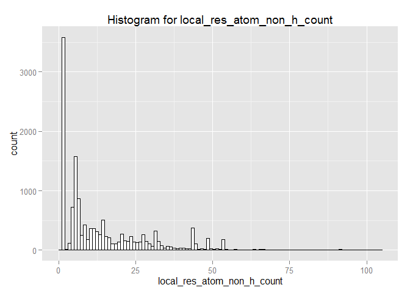

## Rozkład elektronów

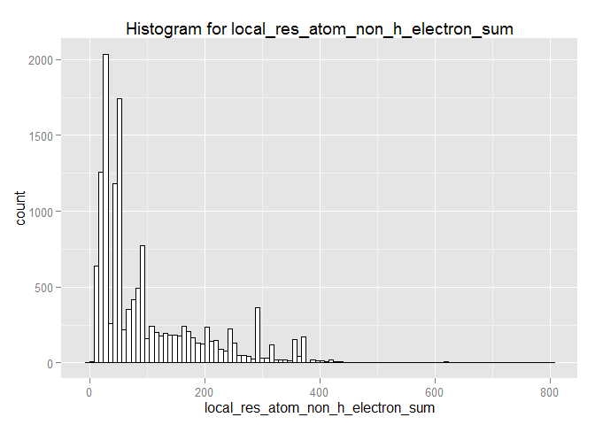

# Próba odtworzenia wykresu z wymagań

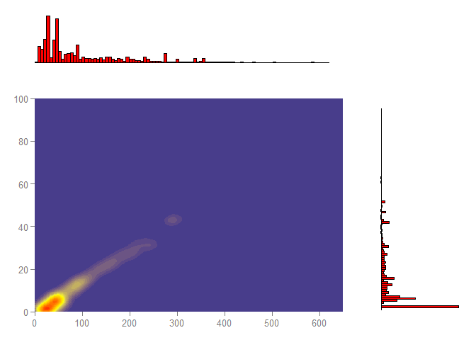

# Klasy z największą niezgodnością liczby atomów

| res_name | local_res_atom_non_h_count | dict_atom_non_h_count | odds |
| --- | --- | --- | --- |
| NAG | 5554 | 5940 | 386 |
| CDL | 677 | 900 | 223 |
| PEU | 33 | 166 | 133 |
| U10 | 315 | 441 | 126 |
| LMT | 454 | 560 | 106 |
| PC1 | 62 | 162 | 100 |
| 12P | 80 | 148 | 68 |
| PLC | 102 | 168 | 66 |
| PEE | 140 | 204 | 64 |
| PTY | 38 | 100 | 62 |

# Klasy z największą niezgodnością liczby elektronów

| res_name | local_res_atom_non_h_electron_sum | dict_atom_non_h_electron_sum | odds |
| --- | --- | --- | --- |
| NAG | 37700 | 40788 | 3088 |
| CDL | 4528 | 5868 | 1340 |
| PEU | 222 | 1108 | 886 |
| U10 | 1946 | 2702 | 756 |
| LMT | 3010 | 3712 | 702 |
| PC1 | 415 | 1050 | 635 |
| SEP | 4904 | 5368 | 464 |
| 12P | 532 | 992 | 460 |
| MAN | 4768 | 5208 | 440 |
| PEE | 892 | 1328 | 436 |

# Rozkład wartości kolumn part_01

Sekcja przedstawia rozkład wartości wszystkich kolumn zaczynających się od part_01

Usunięto wartości NA dla każdej kolumny z osobna. Nie zostały zamienione na wartość 0 by nie zaburzać rozkładu zmiennych.

Na wykresach zaznaczono średnią wartość zmiennej (w formie graficznej oraz liczbowej).

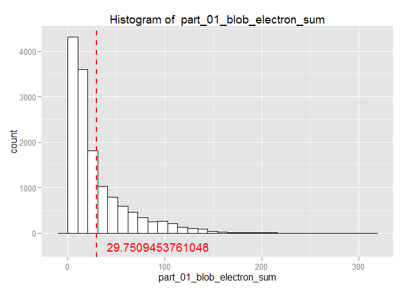

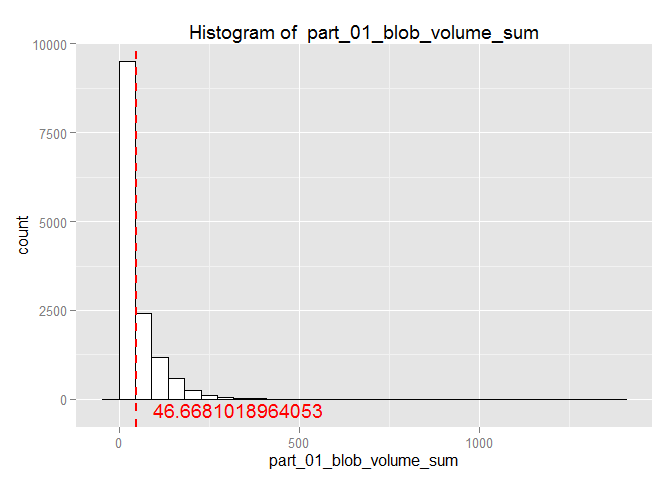

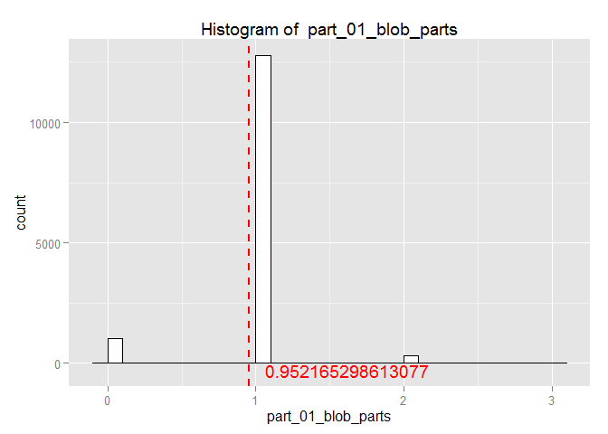

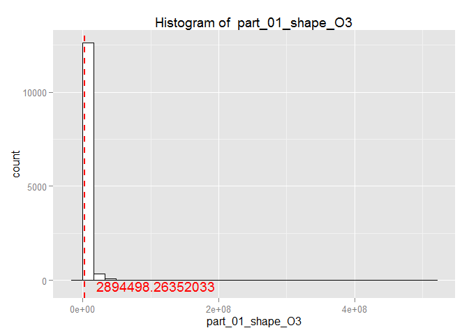

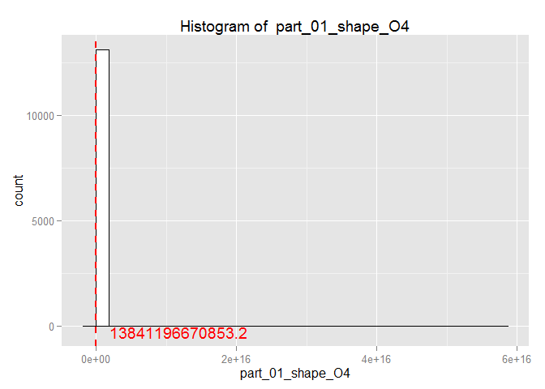

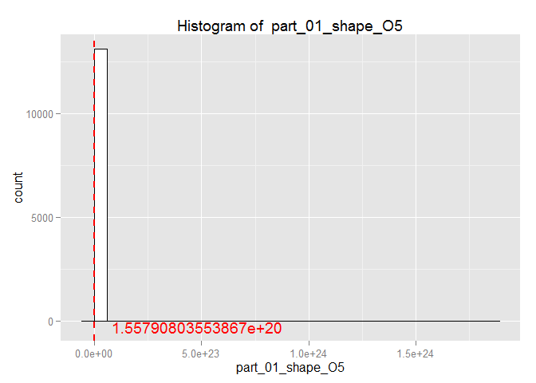

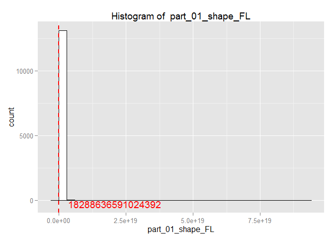

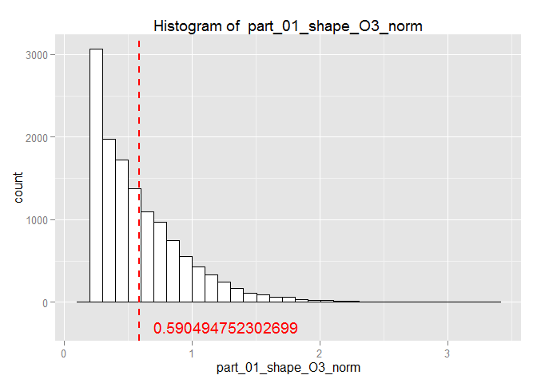

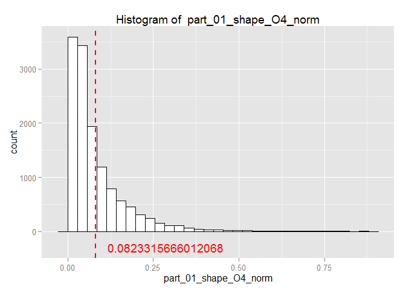

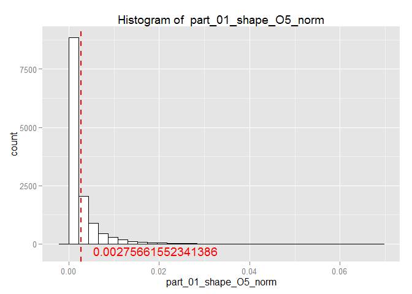

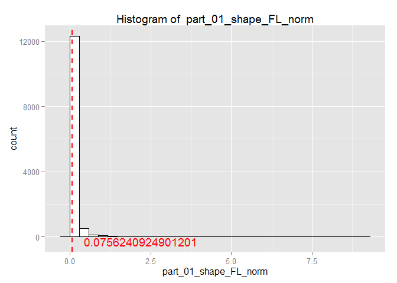

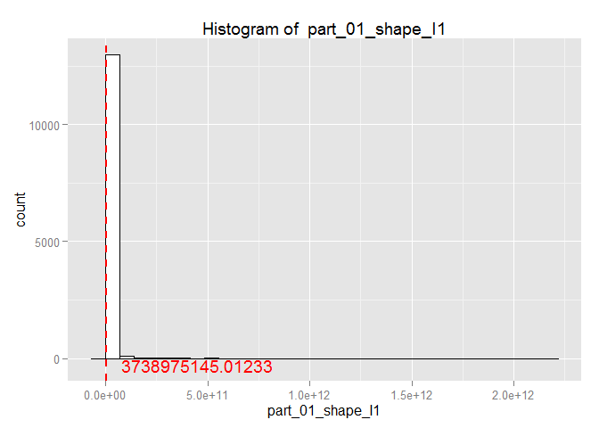

[57 more figures not shown]

# Przewidywanie liczby elektronów i atomów na podstawie innych kolumn

```r
lm_data <- rawData
lm_data[is.na(lm_data)] <- 0
lm_data <- lm_data[sapply(lm_data, is.numeric)]

lm_atom_model <- lm(local_res_atom_non_h_count ~ ., lm_data)
lm_atom_summary <- summary(lm_atom_model)

lm_electron_model <- lm(local_res_atom_non_h_electron_sum ~ ., lm_data)
lm_electron_summary <- summary(lm_electron_model)
```

Miary dla liczby atomów:  
R^2: 0.9999836  
RMSEL 0.0621215

Miary dla liczby elektronów:  
R^2: 0.9999498  
RMSEL 0.728142

# Klasyfikator

Podczas prób budowy klasyfikatora ze zbioru danych wybrano klasy res_name, które mają minimum 50 wystąpień w pliku a następnie na ich podstawie zbudować klasyfikator. Do budowy klasyfikatora użyłem tylko wartośći, które zostały obliczone na podstawie ligandu.